# mpl_toolkits.mplot3d.axes3d.Axes3D.plot_wireframe

**Axes3D.plot_wireframe(*X*, *Y*, *Z*, *, *axlim_clip=False*, **kwargs)[[source]](https://github.com/matplotlib/matplotlib/blob/v3.10.8/lib/mpl_toolkits/mplot3d/axes3d.py#L2324-L2446)**

Plot a 3D wireframe.

Note

The *rcount* and *ccount* kwargs, which both default to 50, determine the maximum number of samples used in each direction. If the input data is larger, it will be downsampled (by slicing) to these numbers of points.

**Parameters:**

**X, Y, Z**2D arrays**

Data values.

**axlim_clip**bool, default: False**

Whether to hide lines and patches with vertices outside the axes view limits.

Added in version 3.10.

**rcount, ccount**int**

Maximum number of samples used in each direction. If the input data is larger, it will be downsampled (by slicing) to these numbers of points. Setting a count to zero causes the data to be not sampled in the corresponding direction, producing a 3D line plot rather than a wireframe plot. Defaults to 50.

**rstride, cstride**int**

Downsampling stride in each direction. These arguments are mutually exclusive with *rcount* and *ccount*. If only one of *rstride* or *cstride* is set, the other defaults to 1. Setting a stride to zero causes the data to be not sampled in the corresponding direction, producing a 3D line plot rather than a wireframe plot.

'classic' mode uses a default of `rstride = cstride = 1` instead of the new default of `rcount = ccount = 50`.

**kwargs**

Other keyword arguments are forwarded to `Line3DCollection`.

## Examples using `mpl_toolkits.mplot3d.axes3d.Axes3D.plot_wireframe`

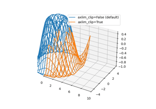

[Clip the data to the axes view limits](https://matplotlib.org/stable/gallery/mplot3d/axlim_clip.html)

Clip the data to the axes view limits

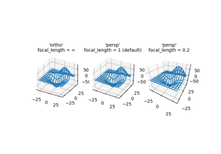

[3D plot projection types](https://matplotlib.org/stable/gallery/mplot3d/projections.html)

3D plot projection types

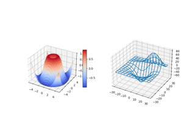

[3D plots as subplots](https://matplotlib.org/stable/gallery/mplot3d/subplot3d.html)

3D plots as subplots

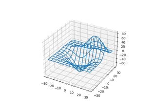

[3D wireframe plot](https://matplotlib.org/stable/gallery/mplot3d/wire3d.html)

3D wireframe plot

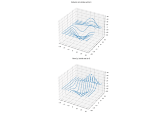

[3D wireframe plots in one direction](https://matplotlib.org/stable/gallery/mplot3d/wire3d_zero_stride.html)

3D wireframe plots in one direction

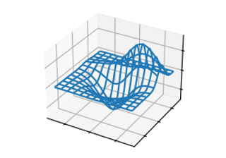

[plot_wireframe(X, Y, Z)](https://matplotlib.org/stable/plot_types/3D/wire3d_simple.html)

plot_wireframe(X, Y, Z)

© 2012–2026 Matplotlib Development Team. All rights reserved.  
Licensed under the Matplotlib License Agreement.  
https://matplotlib.org/stable/api/_as_gen/mpl_toolkits.mplot3d.axes3d.Axes3D.plot_wireframe.html